# R Notebook

# Homework - CIs

### Section 1: MVP

Now we’ll go back to CI creation in the normal fashion. We’ll take the ‘ames’ data from the CIs lab earlier today and regard it now as a sample, we won’t be drawing any smaller samples from within it. This is the usual situation in an analysis: you use all the data available to you!

```r
library(tidyverse)
library(janitor)
library(infer)
library(e1071)
```

*Load the data again, clean_names(), and re-familiarise yourself with it*

Let’s get the dataset.

```r
ames <- read_csv("data/ames.csv")
ames <- clean_names(ames)
```

*Investigate the distribution of lot_area. Is the distribution roughly normal? If not, what problems do you find?*

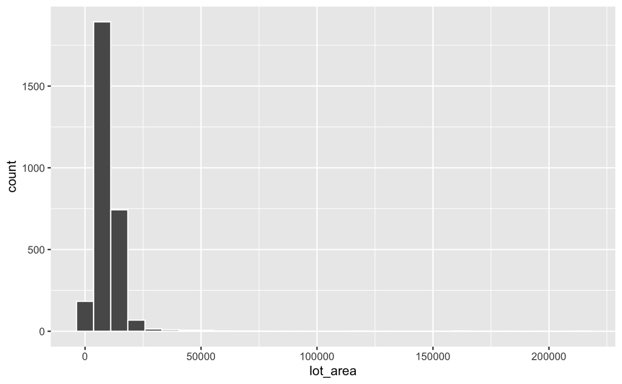

```r
ames %>%
  select(lot_area) %>%
  ggplot() +
  aes(x = lot_area) +
  geom_histogram(col="white", bins=30)
```

```r
ames %>%
  select(lot_area) %>%
  summarise(skewness_dist = skewness(lot_area, type =1))
```

| skewness_dist |
| --- |
| 12.81433 |

*Compute and visualise a bootstrap sampling distribution for the mean(lot_area) of the sold houses.* First, let’s get a sample from our dataset. We get a sample of 300 observations.

```r
single_sample_300 <- ames %>%
  rep_sample_n(size = 300, reps = 1) %>%
  ungroup() %>%
  select(lot_area)
```

Now, we will apply bootsrapping the single sample.

```r
bootstrap_rep_sample_300 <- single_sample_300 %>%
  specify(response = lot_area) %>%
  generate(reps = 10000, type = "bootstrap") %>%
  calculate(stat = "mean")
```

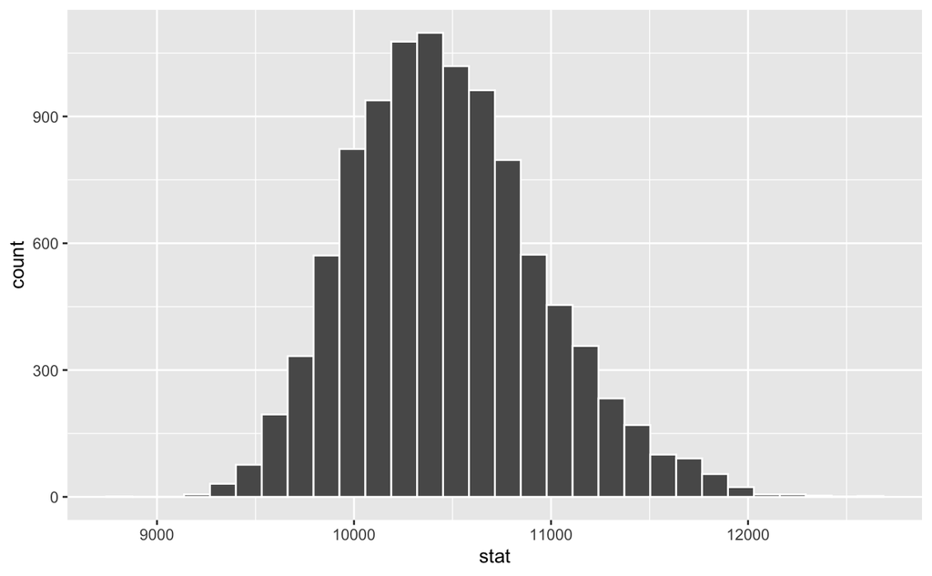

```r
bootstrap_rep_sample_300 %>%
  ggplot()+
  aes(x = stat)+
  geom_histogram(col = "white")
```

*Use your bootstrap distribution to calculate a 95% CI for mean(lot_area), and visualise it on the distribution*

```r
bootstrap_lot_area_ci <- bootstrap_rep_sample_300 %>%
  get_confidence_interval(level = 0.95, type = "percentile")
bootstrap_lot_area_ci
```

| 2.5% | 97.5% |
| --- | --- |
| 9632.53 | 11537.65 |

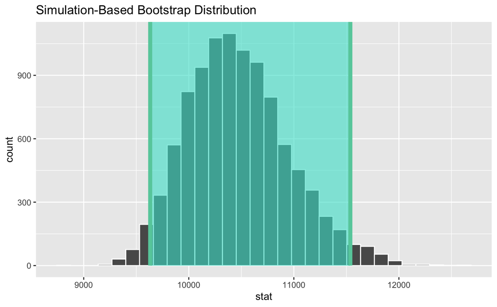

```r
bootstrap_rep_sample_300 %>%
  visualise(bins = 30) +
  shade_confidence_interval(endpoints = bootstrap_lot_area_ci)
```

*You would like to know the mean(lot_area) of the sold houses with higher confidence. Calculate the 99% CI for this variable (you can re-use your bootstrap distribution from above). Is it narrower or broader than the 95% CI? Does that make sense?*

```r
bootstrap_lot_area_ci_99 <- bootstrap_rep_sample_300 %>%
  get_confidence_interval(level = 0.99, type = "percentile")
bootstrap_lot_area_ci_99
```

| 0.5% | 99.5% |
| --- | --- |
| 9425.639 | 11866.63 |

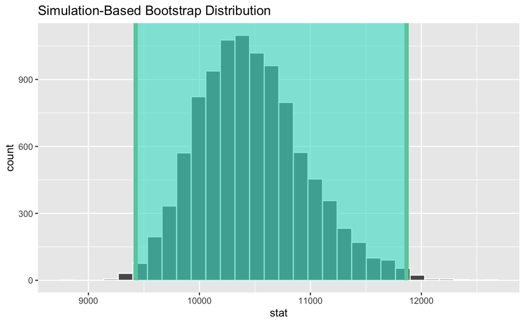

```r
bootstrap_rep_sample_300 %>%
  visualise(bins = 30) +
  shade_confidence_interval(endpoints = bootstrap_lot_area_ci_99)
```

It can be seen now that the confidence interval is wider, therefore there is higher possibility that the mean from our sampling will be included in the interval.

*Calculate the point estimate of the mean(lot_area)*

We also calculate the mean from our bootstrap sampling distribution.

```r
bootstrap_rep_sample_300 %>%
  summarise(mean(stat))
```

| mean(stat) |
| --- |
| 10473.06 |

### Section 2: Extension (Still working on it)

Calculate a point estimate and 95% CI for the proportion of houses in the data built before 1920. Does the number of reps you use matter? [Investigate reps from 200 up to 50000, memory of your laptop permitting].

First, let’s rewrite the colulmn year_built into “Yes” (if houses build before 1920) or “No” otherwise.

```r
ames_old_houses <- ames %>%
  mutate(year_built_new = ifelse(year_built < 1920, "Yes", "No"))
```

Now, let’s get a sample from our new column, called *ames_old_houses*. We get a sample of 200 observations.column **year_built**.

```r
single_sample_year_built <- ames_old_houses %>%
  rep_sample_n(size = 200, reps = 1)
```

We now use bootstrap.

[output not shown]

[output cut: 190 more lines]

```r
bootstrap_prop_ci <- bootstrap_rep_year_built %>%
  get_confidence_interval(level = 0.95, type = "percentile")
bootstrap_prop_ci
```

| 2.5% | 97.5% |
| --- | --- |
| 0.02 | 0.075 |

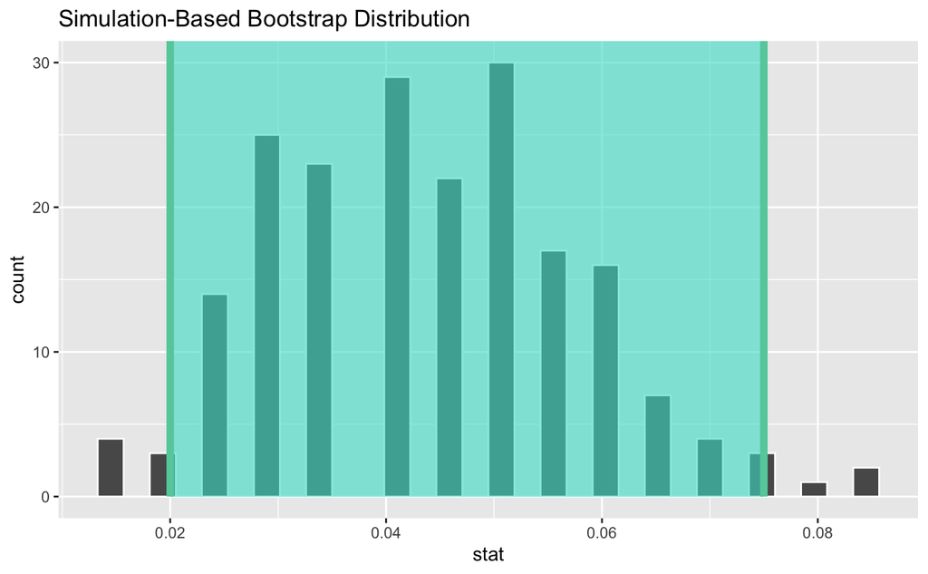

```r
bootstrap_rep_year_built %>%
  visualise(bins = 30) +
  shade_confidence_interval(endpoints = bootstrap_prop_ci)
```

We also calculate the mean from our bootstrap sampling distribution.

```r
bootstrap_rep_year_built %>%
  summarise(mean(stat))
```

[output not shown]